# Homework #2 Answer Key

INFSCI 2160

```r
library(dplyr)
library(readr)
HOMEWORK_2_DATASET_DIRECT_MARKETING <- read_csv("C:/Users/berezom/Desktop/INFSCI 2160/Week 2/Homework/HOMEWORK_2_DATASET_DIRECT_MARKETING.csv")
```

# Question #1: Identify the response variable and the predictor variables

Predictor variables: Age, Gender, OwnHome, Married, Location, Salary, Children, History, Catalogs

Response variable: AmountSpent

# Question #2: Explore the dataset and generate a statistical and graphical summary:

- There are missing values in the dataset. Describe how you deal with them (Hint: Check the data description to see what the missingness means)

#### Question #2 Answer A: There are missing values in the dataset. Describe how you deal with them. (Hint: Check the data description to see what the missingness means.)

There are 303 missing values in History. In the appendix, the data description for NA indicates a new customer that has not purchased yet. This means we can fill in NA with a new category for these customers. (-5 if observations were omitted)

```r
summary(HOMEWORK_2_DATASET_DIRECT_MARKETING)
```

```
##      Age               Gender            OwnHome
##  Length:1000        Length:1000        Length:1000
##  Class :character   Class :character   Class :character
##  Mode  :character   Mode  :character   Mode  :character
##
##
##
##    Married            Location             Salary          Children
##  Length:1000        Length:1000        Min.   : 10100   Min.   :0.000
##  Class :character   Class :character   1st Qu.: 29975   1st Qu.:0.000
##  Mode  :character   Mode  :character   Median : 53700   Median :1.000
##                                        Mean   : 56104   Mean   :0.934
##                                        3rd Qu.: 77025   3rd Qu.:2.000
##                                        Max.   :168800   Max.   :3.000
##    History             Catalogs      AmountSpent
##  Length:1000        Min.   : 6.00   Min.   :  38.0
##  Class :character   1st Qu.: 6.00   1st Qu.: 488.2
##  Mode  :character   Median :12.00   Median : 962.0
##                     Mean   :14.68   Mean   :1216.8
##                     3rd Qu.:18.00   3rd Qu.:1688.5
##                     Max.   :24.00   Max.   :6217.0
```

```r
# Add a new category for customers with NA
levels(HOMEWORK_2_DATASET_DIRECT_MARKETING$History) = c(levels(HOMEWORK_2_DATASET_DIRECT_MARKETING$History), "NewCustomer")
HOMEWORK_2_DATASET_DIRECT_MARKETING$History[is.na(HOMEWORK_2_DATASET_DIRECT_MARKETING$History)] = "NewCustomer"
summary(HOMEWORK_2_DATASET_DIRECT_MARKETING$History)
```

```
##    Length     Class      Mode
##      1000 character character
```

```r
table(HOMEWORK_2_DATASET_DIRECT_MARKETING$History)
```

```
##
##        High         Low      Medium NewCustomer
##         255         230         212         303
```

```r
sum(is.na(HOMEWORK_2_DATASET_DIRECT_MARKETING$History))
```

```
## [1] 0
```

#### Question #2 Answer B: Generate a summary table for the data. For each numerical variable, list the name of it, mean, median, 1st quartile, 3rd quartile, and standard deviation.

There were 4 numerical variables: Salary, Children, Catalogs, AmountSpent. Min, 1st and 3rd quartile, median, mean, max and standard deviation needed to be displayed for these columns in some way. The summary() function does not include standard deviation. -1 for each missed metric, -1 for each missing numerical variable.

```r
Salary = c(summary(HOMEWORK_2_DATASET_DIRECT_MARKETING$Salary), sd(HOMEWORK_2_DATASET_DIRECT_MARKETING$Salary))
Children = c(summary(HOMEWORK_2_DATASET_DIRECT_MARKETING$Children), sd(HOMEWORK_2_DATASET_DIRECT_MARKETING$Children))
Catalogs = c(summary(HOMEWORK_2_DATASET_DIRECT_MARKETING$Catalogs), sd(HOMEWORK_2_DATASET_DIRECT_MARKETING$Catalogs))
AmountSpent = c(summary(HOMEWORK_2_DATASET_DIRECT_MARKETING$AmountSpent), sd(HOMEWORK_2_DATASET_DIRECT_MARKETING$AmountSpent))
result = rbind(Salary, Children, Catalogs, AmountSpent)
result = as.data.frame(result)
colnames(result)[7] = c("sd")
library(knitr)
kable(result, caption = 'Table 1: Summary of attributes')
```

Table 1: Summary of attributes

|  | Min. | 1st Qu. | Median | Mean | 3rd Qu. | Max. | sd |
| --- | --- | --- | --- | --- | --- | --- | --- |
| Salary | 10100 | 29975.00 | 53700 | 56103.900 | 77025.0 | 168800 | 30616.314826 |
| Children | 0 | 0.00 | 1 | 0.934 | 2.0 | 3 | 1.051070 |
| Catalogs | 6 | 6.00 | 12 | 14.682 | 18.0 | 24 | 6.622895 |
| AmountSpent | 38 | 488.25 | 962 | 1216.770 | 1688.5 | 6217 | 961.068612 |

#### Question #2 Answer C: Plot the density distribution of the AmountSpent and Salary variables. What type of shape do they have?

The first plot had right skew and was unimodal. The second plot was right skewed and was bimodal.

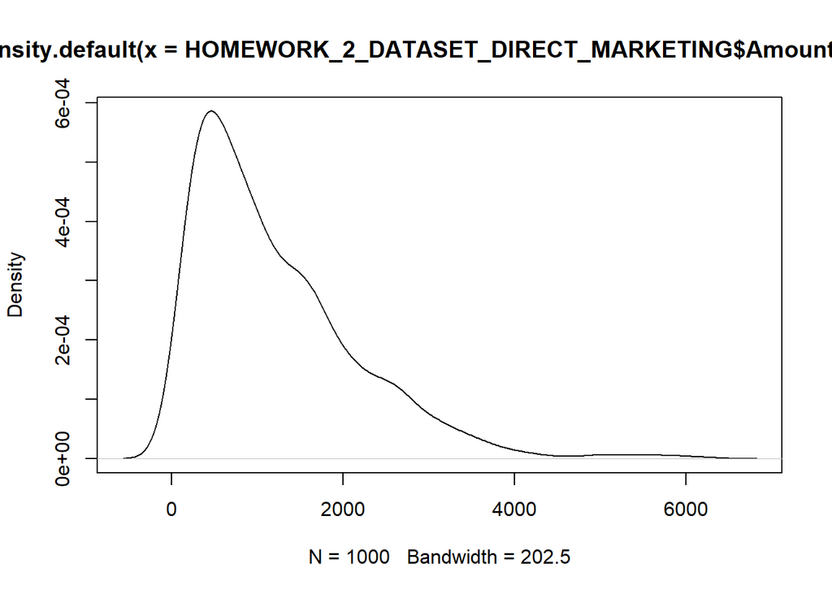

```r
plot(density(HOMEWORK_2_DATASET_DIRECT_MARKETING$AmountSpent))
```

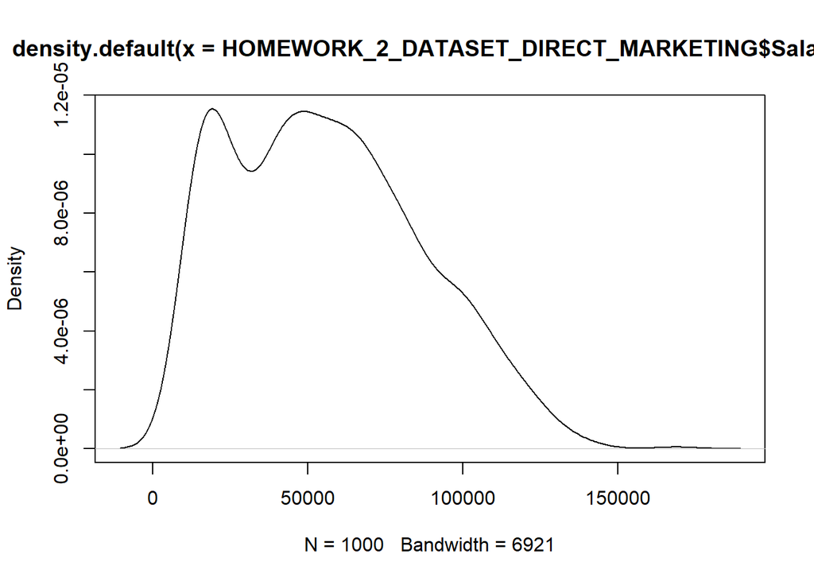

```r
plot(density(HOMEWORK_2_DATASET_DIRECT_MARKETING$Salary))
```

#### Question #2 Answer D: Describe the relationship between all the continuous variables and the response variable in terms of correlation and a scatter plot.

There we 3 numerical independent variables: Children, Catalogs, and Salary. -1 for each missing scatter plot, -1 for each missing variable, -1 for each missing correlation.

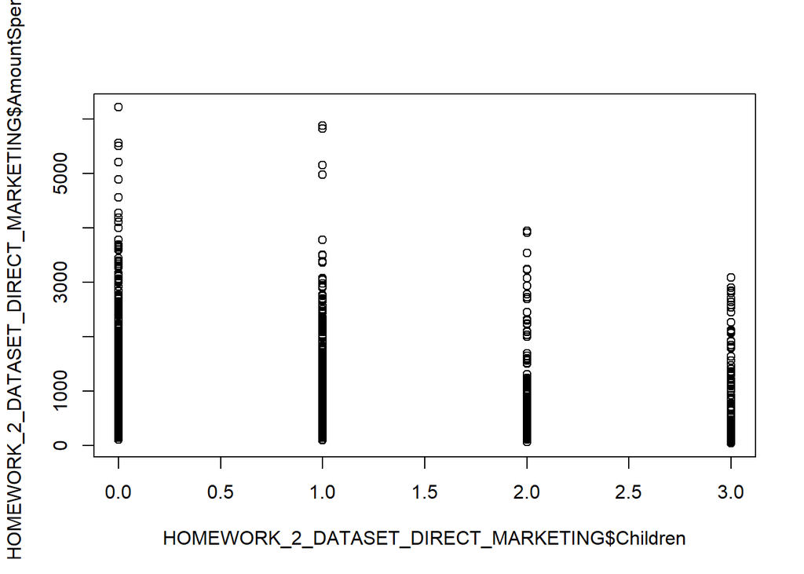

```r
plot(HOMEWORK_2_DATASET_DIRECT_MARKETING$Children, HOMEWORK_2_DATASET_DIRECT_MARKETING$AmountSpent)
```

```r
#Correlation between children and amountspent:
cor(HOMEWORK_2_DATASET_DIRECT_MARKETING$Children, HOMEWORK_2_DATASET_DIRECT_MARKETING$AmountSpent)
```

```
## [1] -0.2223082
```

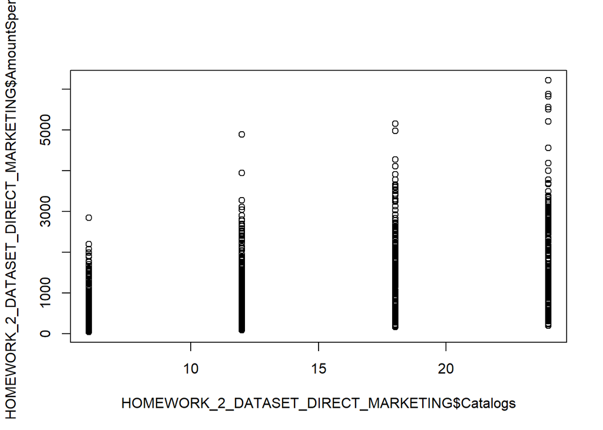

```r
plot(HOMEWORK_2_DATASET_DIRECT_MARKETING$Catalogs, HOMEWORK_2_DATASET_DIRECT_MARKETING$AmountSpent)
```

```r
#Correlation between catalogs and amountspent:
cor(HOMEWORK_2_DATASET_DIRECT_MARKETING$Catalogs, HOMEWORK_2_DATASET_DIRECT_MARKETING$AmountSpent)
```

```
## [1] 0.4726499
```

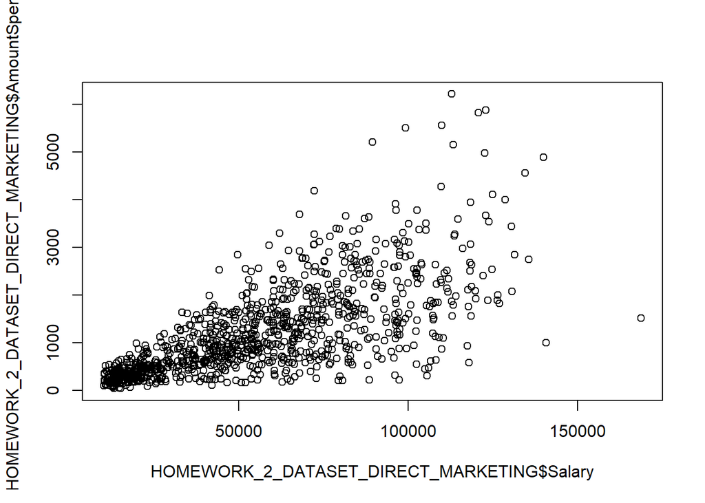

```r
plot(HOMEWORK_2_DATASET_DIRECT_MARKETING$Salary, HOMEWORK_2_DATASET_DIRECT_MARKETING$AmountSpent)
```

```r
#Correlation between salary and amountspent:
cor(HOMEWORK_2_DATASET_DIRECT_MARKETING$Salary, HOMEWORK_2_DATASET_DIRECT_MARKETING$AmountSpent)
```

```
## [1] 0.6995957
```

#### Question #2 Answer E: For each categorical variable, generate a conditional density plot of the response variable. (Hint: Plot the density of the response variable into multiple distributions separated by the predictor’s categories on the same figure. Use different colors or line shapes to differentiate the categories.)

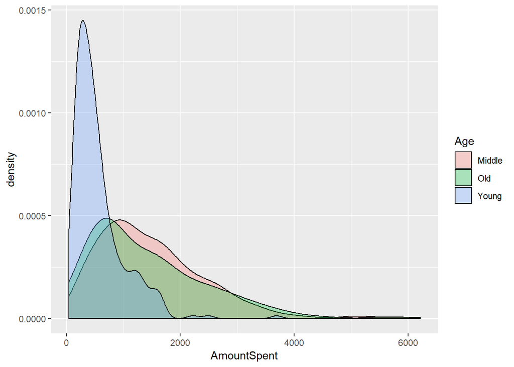

```r
library(ggplot2)
ggplot(HOMEWORK_2_DATASET_DIRECT_MARKETING, aes(x=AmountSpent)) + geom_density(aes(group=Age, fill=Age), alpha=.3)
```

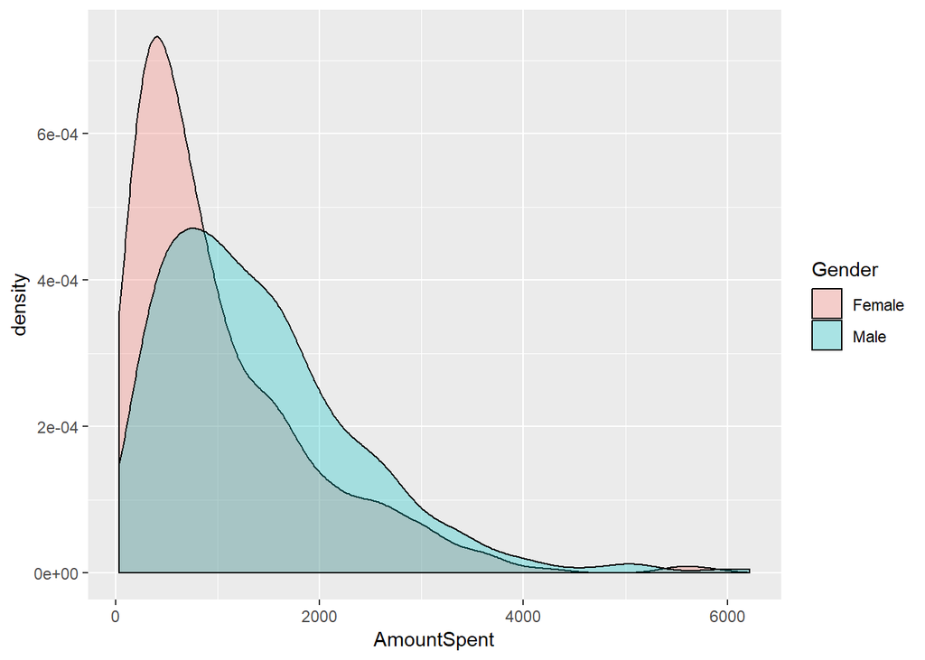

```r
ggplot(HOMEWORK_2_DATASET_DIRECT_MARKETING, aes(x=AmountSpent)) + geom_density(aes(group=Gender, fill=Gender), alpha=.3)
```

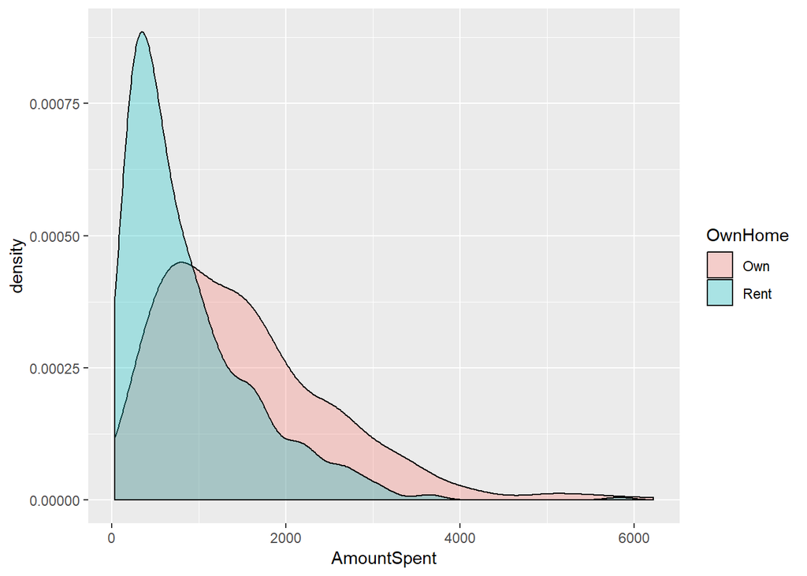

```r
ggplot(HOMEWORK_2_DATASET_DIRECT_MARKETING, aes(x=AmountSpent)) + geom_density(aes(group=OwnHome, fill=OwnHome), alpha=.3)
```

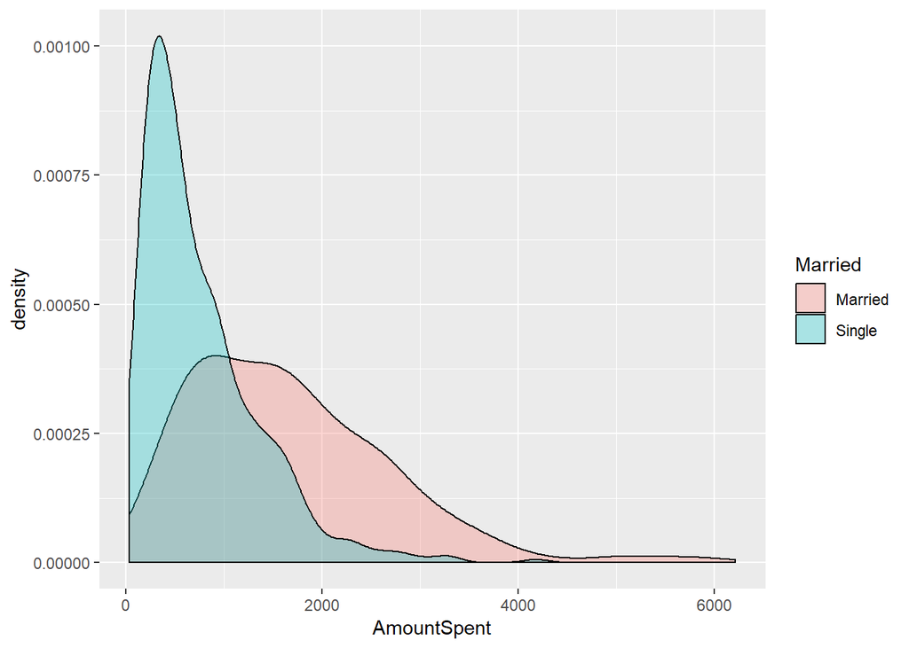

```r
ggplot(HOMEWORK_2_DATASET_DIRECT_MARKETING, aes(x=AmountSpent)) + geom_density(aes(group=Married, fill=Married), alpha=.3)
```

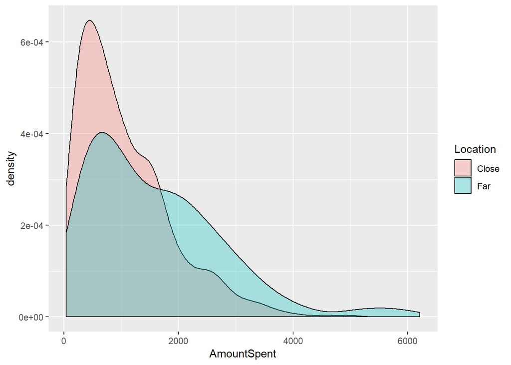

```r
ggplot(HOMEWORK_2_DATASET_DIRECT_MARKETING, aes(x=AmountSpent)) + geom_density(aes(group=Location, fill=Location), alpha=.3)
```

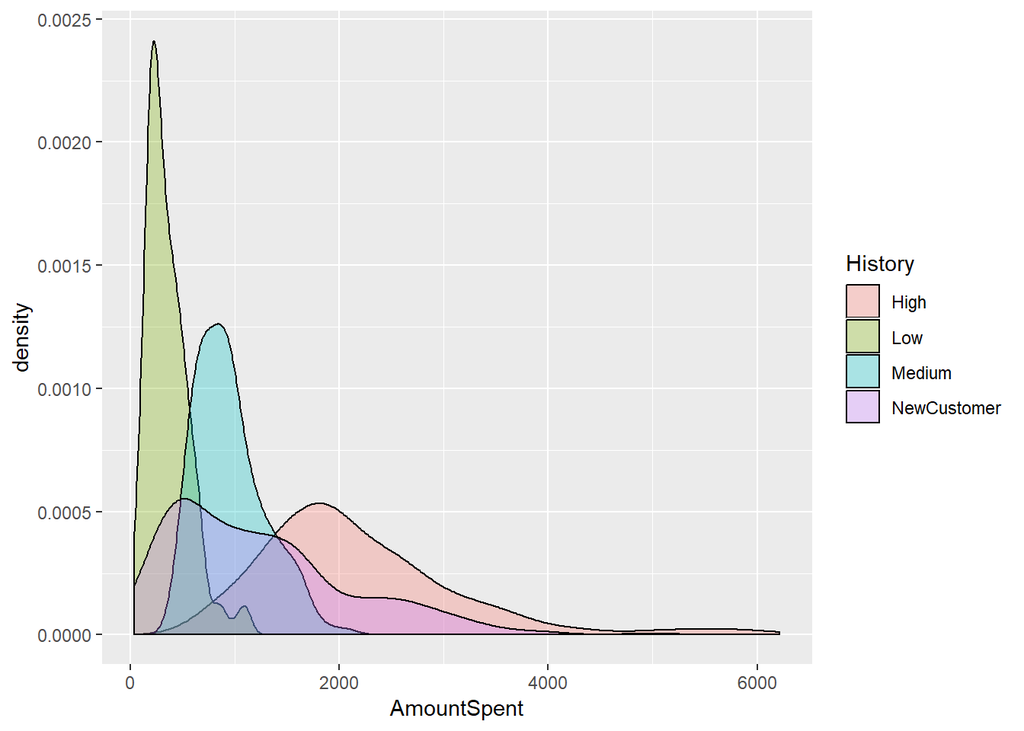

```r
ggplot(HOMEWORK_2_DATASET_DIRECT_MARKETING, aes(x=AmountSpent)) + geom_density(aes(group=History, fill=History), alpha=.3)
```

# Question #3: Apply regression analysis to the dataset to predict AmountSpent.

#### Question #3 A: Run a multiple linear regression model. How does it perform?

A few things were expected here:

- Seed needed to be set (-2.5 if not set)
- Data needed to be partitioned into a training and test set (-5 if not split)
- Multiple linear regression model needed to be run successfully (-1 if not successful)
- Performance needed to be measured by some relevant metric discussed in class: mean squared error, root mean squared error, r-squared or adjusted r-squared. Test set should have been emphasized as our main evaluation. (-1 if no metric cited or metric is incorrect)

We found the train RMSE to be 456.2954 and the test RMSE to be 544.5544. While we are not surprised the training set performs better, the model does not seem to overfit.

```r
library(rsample)
set.seed(150)
hw2_train_test_split <- initial_split(HOMEWORK_2_DATASET_DIRECT_MARKETING, prop = 0.70)
hw2_train_tbl <- training(hw2_train_test_split)
hw2_test_tbl  <- testing(hw2_train_test_split)

fit <- lm(AmountSpent ~ ., data = hw2_train_tbl)
summary(fit)
```

```
##
## Call:
## lm(formula = AmountSpent ~ ., data = hw2_train_tbl)
##
## Residuals:
##      Min       1Q   Median       3Q      Max
## -1652.56  -274.23   -30.81   230.22  2905.09
##
## Coefficients:
##                      Estimate Std. Error t value Pr(>|t|)
## (Intercept)        -3.056e+02  1.320e+02  -2.316   0.0209 *
## AgeOld              1.141e+02  5.337e+01   2.137   0.0329 *
## AgeYoung            5.091e+01  5.673e+01   0.897   0.3699
## GenderMale         -6.443e+01  3.695e+01  -1.744   0.0816 .
## OwnHomeRent         2.115e+01  4.186e+01   0.505   0.6136
## MarriedSingle       3.267e+01  4.996e+01   0.654   0.5135
## LocationFar         4.298e+02  4.069e+01  10.563  < 2e-16 ***
## Salary              1.875e-02  1.171e-03  16.018  < 2e-16 ***
## Children           -1.594e+02  2.055e+01  -7.756 3.17e-14 ***
## HistoryLow         -3.989e+02  7.332e+01  -5.440 7.40e-08 ***
## HistoryMedium      -4.055e+02  5.944e+01  -6.823 1.96e-11 ***
## HistoryNewCustomer  1.302e+01  5.834e+01   0.223   0.8234
## Catalogs            4.254e+01  2.833e+00  15.019  < 2e-16 ***
## ---
## Signif. codes:  0 '***' 0.001 '**' 0.01 '*' 0.05 '.' 0.1 ' ' 1
##
## Residual standard error: 460.6 on 687 degrees of freedom
## Multiple R-squared:  0.7577, Adjusted R-squared:  0.7534
## F-statistic:   179 on 12 and 687 DF,  p-value: < 2.2e-16
```

```r
hw2_test_w_preds <- hw2_test_tbl %>%
  mutate(amount_spent_test_preds = predict(fit, hw2_test_tbl))

test_errors <- (hw2_test_w_preds$AmountSpent - hw2_test_w_preds$amount_spent_test_preds)

#I evaluated the model by root mean squared error:
sqrt(mean(test_errors^2))
```

```
## [1] 544.5544
```

```r
#Find train RMSE:
RSS <- c(crossprod(fit$residuals))
MSE <- RSS / length(fit$residuals)
RMSE <- sqrt(MSE)
RMSE
```

```
## [1] 456.2954
```

#### Question #3 B: Use ridge, lasso, and AIC for feature selection. For each model:

- Identify which variables are statistically significant.
- Evaluate the performance of your model.
- Which model performed best? How did you decide this?

A few things were expected here:

- Seed needed to be set (if not yet set) (-2.5 if not set)
- Data needed to be partitioned into a training and test set (-5 if not split)
- AIC model needed to be to be run successfully and applied to test data (-1 if not successful)
- LASSO model needed to be to be run successfully and applied to test data (-1 if not successful). Lambda needed to be chosen with some cross-validation technique on training data.
- Ridge model needed to be to be run successfully and applied to test data (-1 if not successful). Lambda needed to be chosen with some cross-validation technique on training data.
- Performance needed to be measured by some relevant metric discussed in class across all 3 models against the same testing data: mean squared error, root mean squared error, r-squared or adjusted r-squared. Test set should have been emphasized as our main evaluation. (-1 if no metric cited or metric is incorrect), (-5 if incorrect interpretation of best model)

```r
#AIC Model:
library(MASS)
library(glmnet)
hw2_lm_stepwise_backward <- stepAIC(fit, direction = "backward")
```

```
## Start:  AIC=8598.4
## AmountSpent ~ Age + Gender + OwnHome + Married + Location + Salary +
##     Children + History + Catalogs
##
##            Df Sum of Sq       RSS    AIC
## - OwnHome   1     54136 145797973 8596.7
## - Married   1     90678 145834515 8596.8
## <none>                  145743837 8598.4
## - Age       2    974668 146718505 8599.1
## - Gender    1    645269 146389106 8599.5
## - Children  1  12761392 158505229 8655.2
## - History   3  22475645 168219482 8692.8
## - Location  1  23671509 169415346 8701.7
## - Catalogs  1  47852065 193595902 8795.1
## - Salary    1  54428257 200172094 8818.5
##
## Step:  AIC=8596.66
## AmountSpent ~ Age + Gender + Married + Location + Salary + Children +
##     History + Catalogs
##
##            Df Sum of Sq       RSS    AIC
## - Married   1     79734 145877707 8595.0
## <none>                  145797973 8596.7
## - Age       2    934664 146732637 8597.1
## - Gender    1    653363 146451336 8597.8
## - Children  1  12960283 158758256 8654.3
## - History   3  22424179 168222152 8690.8
## - Location  1  23903712 169701685 8700.9
## - Catalogs  1  47815543 193613516 8793.2
## - Salary    1  56328971 202126944 8823.3
##
## Step:  AIC=8595.04
## AmountSpent ~ Age + Gender + Location + Salary + Children + History +
##     Catalogs
##
##            Df Sum of Sq       RSS    AIC
## <none>                  145877707 8595.0
## - Age       2    860086 146737793 8595.2
## - Gender    1    623072 146500779 8596.0
## - Children  1  12972392 158850099 8652.7
## - History   3  22775509 168653216 8690.6
## - Location  1  23827907 169705615 8698.9
## - Catalogs  1  47750994 193628701 8791.3
## - Salary    1  86848223 232725930 8920.0
```

```r
hw2_lm_stepwise_backward
```

```
##
## Call:
## lm(formula = AmountSpent ~ Age + Gender + Location + Salary +
##     Children + History + Catalogs, data = hw2_train_tbl)
##
## Coefficients:
##        (Intercept)              AgeOld            AgeYoung
##         -242.83206           103.97348            45.23098
##         GenderMale         LocationFar              Salary
##          -63.12478           429.93322             0.01819
##           Children          HistoryLow       HistoryMedium
##         -160.23151          -397.08695          -407.90493
## HistoryNewCustomer            Catalogs
##           13.08443            42.48350
```

```r
summary(hw2_lm_stepwise_backward)
```

```
##
## Call:
## lm(formula = AmountSpent ~ Age + Gender + Location + Salary +
##     Children + History + Catalogs, data = hw2_train_tbl)
##
## Residuals:
##      Min       1Q   Median       3Q      Max
## -1611.58  -275.13   -26.89   226.12  2915.67
##
## Coefficients:
##                      Estimate Std. Error t value Pr(>|t|)
## (Intercept)        -2.428e+02  1.039e+02  -2.338   0.0197 *
## AgeOld              1.040e+02  5.178e+01   2.008   0.0450 *
## AgeYoung            4.523e+01  5.305e+01   0.853   0.3942
## GenderMale         -6.312e+01  3.680e+01  -1.715   0.0867 .
## LocationFar         4.299e+02  4.053e+01  10.609  < 2e-16 ***
## Salary              1.819e-02  8.982e-04  20.253  < 2e-16 ***
## Children           -1.602e+02  2.047e+01  -7.828 1.88e-14 ***
## HistoryLow         -3.971e+02  7.314e+01  -5.429 7.87e-08 ***
## HistoryMedium      -4.079e+02  5.914e+01  -6.898 1.20e-11 ***
## HistoryNewCustomer  1.308e+01  5.828e+01   0.225   0.8224
## Catalogs            4.248e+01  2.829e+00  15.018  < 2e-16 ***
## ---
## Signif. codes:  0 '***' 0.001 '**' 0.01 '*' 0.05 '.' 0.1 ' ' 1
##
## Residual standard error: 460.1 on 689 degrees of freedom
## Multiple R-squared:  0.7575, Adjusted R-squared:  0.7539
## F-statistic: 215.2 on 10 and 689 DF,  p-value: < 2.2e-16
```

```r
hw2_test_w_preds <- hw2_test_w_preds %>%
  mutate(amount_spent_test_preds_aic = predict(hw2_lm_stepwise_backward, hw2_test_tbl))

#LASSO MODEL:
#Create grid:
grid <- 10^seq(10,-2,length=1000)

hw2_vars_train <- hw2_train_tbl[, c("Age", "Gender", "OwnHome", "Married", "Location", "Salary", "Children", "History", "Catalogs")]
hw2_vars_test <- hw2_test_tbl[, c("Age", "Gender", "OwnHome", "Married", "Location", "Salary", "Children", "History", "Catalogs")]

hw2_vars_train[, c("Age", "Gender", "OwnHome", "Married", "Location", "Salary", "Children", "History", "Catalogs")] <- lapply(hw2_vars_train[, c("Age", "Gender", "OwnHome", "Married", "Location", "Salary", "Children", "History", "Catalogs")], as.factor)
hw2_vars_train[, c("Age", "Gender", "OwnHome", "Married", "Location", "Salary", "Children", "History", "Catalogs")] <- lapply(hw2_vars_train[, c("Age", "Gender", "OwnHome", "Married", "Location", "Salary", "Children", "History", "Catalogs")], as.numeric)

hw2_vars_test[, c("Age", "Gender", "OwnHome", "Married", "Location", "Salary", "Children", "History", "Catalogs")] <- lapply(hw2_vars_test[, c("Age", "Gender", "OwnHome", "Married", "Location", "Salary", "Children", "History", "Catalogs")], as.factor)
hw2_vars_test[, c("Age", "Gender", "OwnHome", "Married", "Location", "Salary", "Children", "History", "Catalogs")] <- lapply(hw2_vars_test[, c("Age", "Gender", "OwnHome", "Married", "Location", "Salary", "Children", "History", "Catalogs")], as.numeric)

hw2_target_train <- hw2_train_tbl$AmountSpent
hw2_target_test <- hw2_test_tbl$AmountSpent

hw2r_lasso_model <- glmnet(x = as.matrix(hw2_vars_train), y = hw2_target_train, alpha=1, lambda = grid)
hw2r_lasso_model
```

[output not shown]

[output cut: 989 more lines]

```r
summary(hw2r_lasso_model)
```

```
##           Length Class     Mode
## a0        1000   -none-    numeric
## beta      9000   dgCMatrix S4
## df        1000   -none-    numeric
## dim          2   -none-    numeric
## lambda    1000   -none-    numeric
## dev.ratio 1000   -none-    numeric
## nulldev      1   -none-    numeric
## npasses      1   -none-    numeric
## jerr         1   -none-    numeric
## offset       1   -none-    logical
## call         5   -none-    call
## nobs         1   -none-    numeric
```

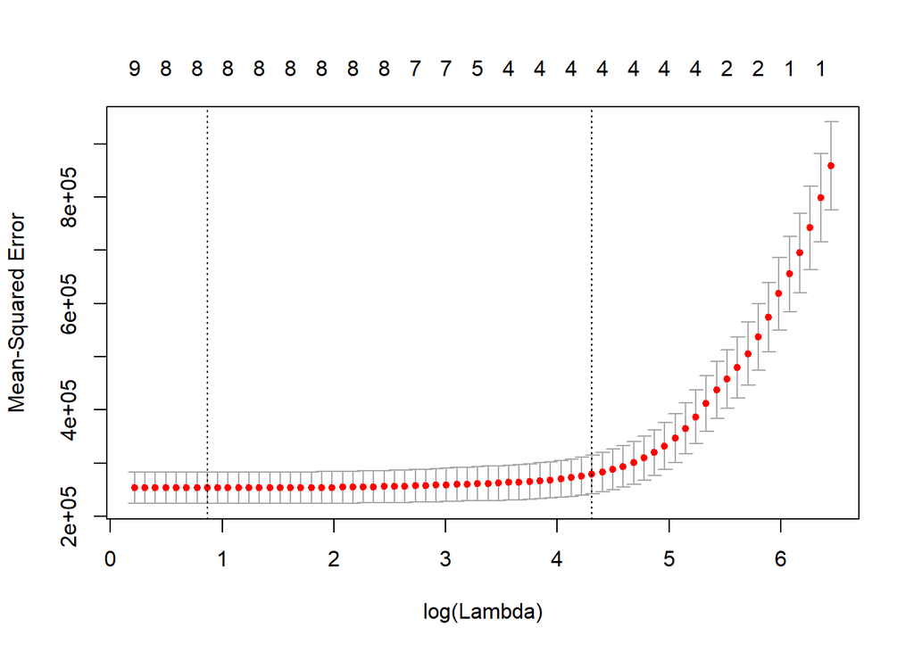

```r
hw2_cv_lasso <- cv.glmnet(x = as.matrix(hw2_vars_train), y = hw2_target_train, alpha=1)
plot(hw2_cv_lasso, label=TRUE)
```

```r
#We can then find our best value for lambda:
bestlam_hw2 <- hw2_cv_lasso$lambda.min
bestlam_hw2
```

```
## [1] 2.382028
```

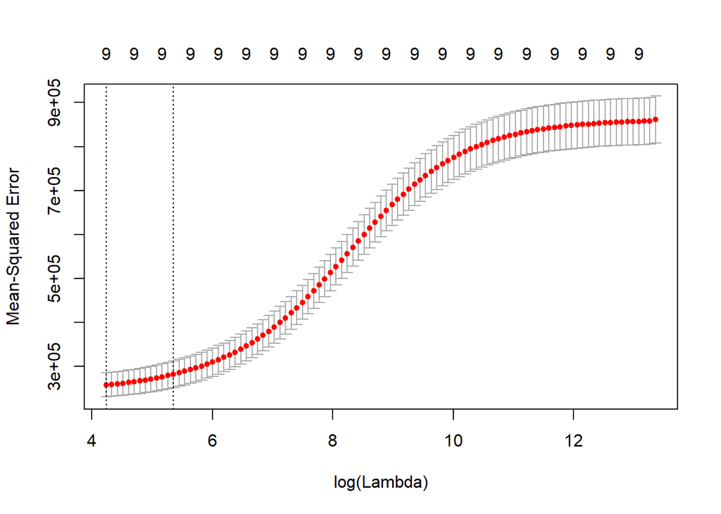

```r
#Test MSE of LASSO and ridge
lasso_pred_hw2 <- predict(hw2_cv_lasso, s = bestlam_hw2, newx = as.matrix(hw2_vars_test))

#Ridge model:
hw2_cv_ridge <- cv.glmnet(x = as.matrix(hw2_vars_train), y = hw2_target_train, alpha=0)
plot(hw2_cv_ridge, label=TRUE)
```

```r
hw2_cv_ridge$lambda.min
```

```
## [1] 69.43739
```

```r
ridge_pred_hw2 <- predict(hw2_cv_ridge, s = hw2_cv_ridge$lambda.min, newx = as.matrix(hw2_vars_test))

#Evaluate all the models by MSE:
mse_hw2_lasso <- mean((lasso_pred_hw2 - hw2_test_w_preds$AmountSpent)^2)
mse_hw2_ridge <- mean((ridge_pred_hw2 - hw2_test_w_preds$AmountSpent)^2)
mse_hw2_aic <- mean((hw2_test_w_preds$amount_spent_test_preds_aic - hw2_test_w_preds$AmountSpent)^2)

mse_hw2_lasso
```

```
## [1] 827733
```

```r
mse_hw2_ridge
```

```
## [1] 674927.1
```

```r
mse_hw2_aic
```

```
## [1] 295953.6
```

```r
#AIC has the smallest MSE in this case on the testing data and peformed the best.
```